# Prosper Loan Data

## by Franck Alain Binde Koube

## Dataset Overview

This data set contains 113,937 loans with 81 variables on each loan, including loan amount, borrower rate (or interest rate), current loan status, borrower income, and many others. All the descriptions about the columns could be find [here](https://docs.google.com/spreadsheets/u/0/d/1gDyi_L4UvIrLTEC6Wri5nbaMmkGmLQBk-Yx3z0XDEtI/edit?usp=sharing). It is strongly recommended to have a look at the variables description to better understand the data.

[figure not shown]

## Investigation Overview

My interest was about understanding the factors that may affect the loan status, the loan original amount and the borrower rate.

### Is there a correlation between our numeric variables?

The only correlation that needs our attention is the one between `ProsperScore` and `BorrowerRate`. There is a relatively strong and negative correlation (r = -0.717) between these two variables. That means, when the ProsperScore increases, the Borrower Rate tend to decrease. This is understandable. A higher prosper score means a loan with less risk. The lower the interest rate (low `BorrowerRate`), the lower the risk (high `ProsperScore`) to pay back.

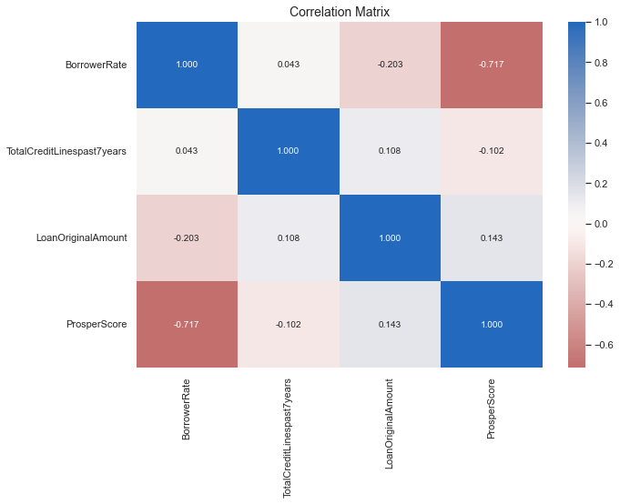

### Hos does the borrower rate impact the loan status?

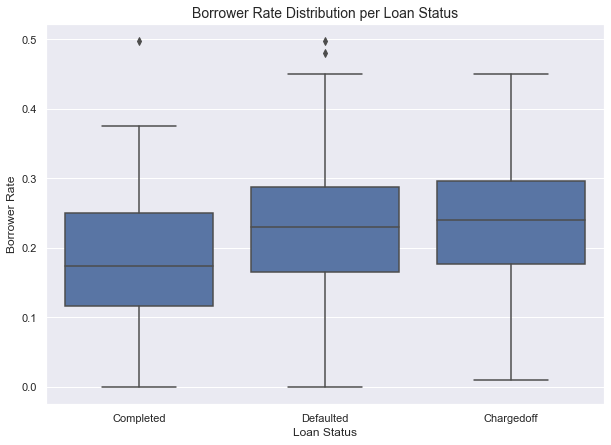

### Does the `Term` impact the loan original amount?

Long term loans are in general more expensive (since there is more time to complete the payment). The median of the loan amount for a 60-months loan is much higher that the ones for 12 and 36 months.

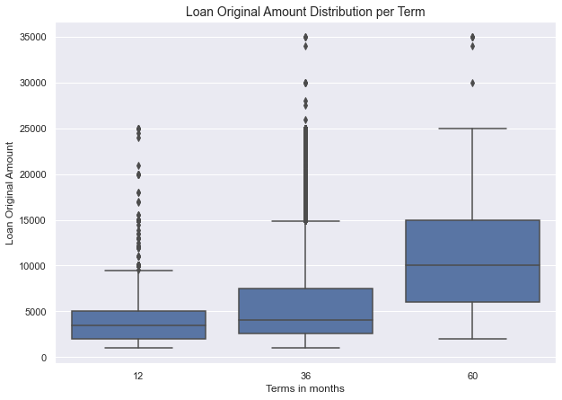

### Do combined features like owning a home and the loan original amount impact the loan status?

Regardless of the loan status, **home owners tend to acquire more expensive loans**. Indeed, the median and 3rd quartile of loan amounts are higher for home owners. On the other hand, owning a home doesn't seem to have a significant impact on the loan status. The main fact we can mention is the long trail for completed loans (showing very high value for loan amounts).

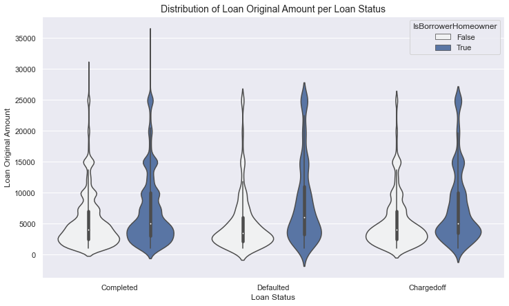

### Do combined features like employment status and the loan original amount impact the loan status?

What are some key findings:

- **Self-employed** people with **completed loans** have a much lower median loan amount that self-employed with defaulted loans.
- The highest Interquartile Range is definitely for **self-employed** with **defaulted loans**. This means that most of the loans for the subset of the data are very spread.

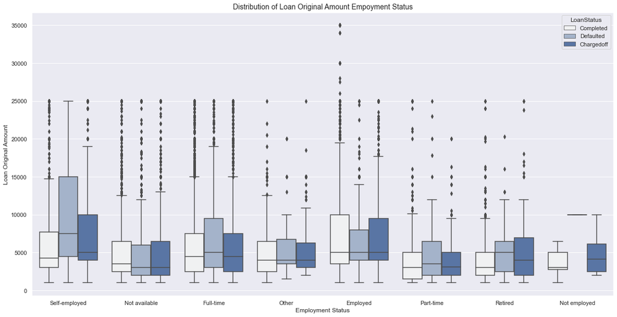